# Data Mining

Jake Harvey

2025-02-17

# Project Part 1

# 1.

## Electric Vehicle Population in Washington

| VIN..1.10. | County | City | State | Postal.Code | Model.Year | Make | Model | Electric.Vehicle.Type | Clean.Alternative.Fuel.Vehicle..CAFV..Eligibility | Electric.Range | Base.MSRP | Legislative.District | DOL.Vehicle.ID | Vehicle.Location | Electric.Utility | X2020.Census.Tract |
| --- | --- | --- | --- | --- | --- | --- | --- | --- | --- | --- | --- | --- | --- | --- | --- | --- |
| WBY8P4C55K | King | Bothell | WA | 98011 | 2019 | BMW | I3 | Plug-in Hybrid Electric Vehicle (PHEV) | Clean Alternative Fuel Vehicle Eligible | 126 | 0 | 1 | 249382416 | POINT (-122.20563 47.76144) | PUGET SOUND ENERGY INC\|\|CITY OF TACOMA - (WA) | 53033021804 |
| KNDCE3LG1K | Thurston | Olympia | WA | 98502 | 2019 | KIA | NIRO | Battery Electric Vehicle (BEV) | Clean Alternative Fuel Vehicle Eligible | 239 | 0 | 22 | 102638791 | POINT (-122.92333 47.03779) | PUGET SOUND ENERGY INC | 53067011100 |
| 5YJYGDEE8L | King | Seattle | WA | 98125 | 2020 | TESLA | MODEL Y | Battery Electric Vehicle (BEV) | Clean Alternative Fuel Vehicle Eligible | 291 | 0 | 46 | 112603774 | POINT (-122.30253 47.72656) | CITY OF SEATTLE - (WA)\|CITY OF TACOMA - (WA) | 53033000202 |
| 1N4AZ0CP0F | Thurston | Olympia | WA | 98506 | 2015 | NISSAN | LEAF | Battery Electric Vehicle (BEV) | Clean Alternative Fuel Vehicle Eligible | 84 | 0 | 22 | 187006893 | POINT (-122.87741 47.05997) | PUGET SOUND ENERGY INC | 53067010300 |
| WA1E2AFY8R | King | Seattle | WA | 98119 | 2024 | AUDI | Q5 E | Plug-in Hybrid Electric Vehicle (PHEV) | Not eligible due to low battery range | 23 | 0 | 36 | 271736741 | POINT (-122.3684 47.64586) | CITY OF SEATTLE - (WA)\|CITY OF TACOMA - (WA) | 53033006900 |
| WA1VAAGEXK | Kitsap | Silverdale | WA | 98383 | 2019 | AUDI | E-TRON | Battery Electric Vehicle (BEV) | Clean Alternative Fuel Vehicle Eligible | 204 | 0 | 23 | 272709076 | POINT (-122.69275 47.65171) | PUGET SOUND ENERGY INC | 53035091302 |

# 2.

## A.

I am going to use the Electric Range for this first part. While looking at this data I discovered that instead of NA they use 0 to show no information, so I will do the equations with 0’s included and excluded.

Excluding 0

| VIN..1.10. | County | City | State | Postal.Code | Model.Year | Make | Model | Electric.Vehicle.Type | Clean.Alternative.Fuel.Vehicle..CAFV..Eligibility | Electric.Range | Base.MSRP | Legislative.District | DOL.Vehicle.ID | Vehicle.Location | Electric.Utility | X2020.Census.Tract |
| --- | --- | --- | --- | --- | --- | --- | --- | --- | --- | --- | --- | --- | --- | --- | --- | --- |
| WBY8P4C55K | King | Bothell | WA | 98011 | 2019 | BMW | I3 | Plug-in Hybrid Electric Vehicle (PHEV) | Clean Alternative Fuel Vehicle Eligible | 126 | 0 | 1 | 249382416 | POINT (-122.20563 47.76144) | PUGET SOUND ENERGY INC\|\|CITY OF TACOMA - (WA) | 53033021804 |
| KNDCE3LG1K | Thurston | Olympia | WA | 98502 | 2019 | KIA | NIRO | Battery Electric Vehicle (BEV) | Clean Alternative Fuel Vehicle Eligible | 239 | 0 | 22 | 102638791 | POINT (-122.92333 47.03779) | PUGET SOUND ENERGY INC | 53067011100 |
| 5YJYGDEE8L | King | Seattle | WA | 98125 | 2020 | TESLA | MODEL Y | Battery Electric Vehicle (BEV) | Clean Alternative Fuel Vehicle Eligible | 291 | 0 | 46 | 112603774 | POINT (-122.30253 47.72656) | CITY OF SEATTLE - (WA)\|CITY OF TACOMA - (WA) | 53033000202 |
| 1N4AZ0CP0F | Thurston | Olympia | WA | 98506 | 2015 | NISSAN | LEAF | Battery Electric Vehicle (BEV) | Clean Alternative Fuel Vehicle Eligible | 84 | 0 | 22 | 187006893 | POINT (-122.87741 47.05997) | PUGET SOUND ENERGY INC | 53067010300 |
| WA1E2AFY8R | King | Seattle | WA | 98119 | 2024 | AUDI | Q5 E | Plug-in Hybrid Electric Vehicle (PHEV) | Not eligible due to low battery range | 23 | 0 | 36 | 271736741 | POINT (-122.3684 47.64586) | CITY OF SEATTLE - (WA)\|CITY OF TACOMA - (WA) | 53033006900 |
| WA1VAAGEXK | Kitsap | Silverdale | WA | 98383 | 2019 | AUDI | E-TRON | Battery Electric Vehicle (BEV) | Clean Alternative Fuel Vehicle Eligible | 204 | 0 | 23 | 272709076 | POINT (-122.69275 47.65171) | PUGET SOUND ENERGY INC | 53035091302 |

### Mean

With 0

```
## [1] 47.73619
```

With the amount of zeros that are in this dataset, it is no wonder that the mean is this low.

Without 0

```
## [1] 114.3081
```

Now that the zeros are gone, a more reasonable mean remains. The ranges are not even, with the majority of them falling below 100 miles. It is still able to overcome 100 with the remaining cars that are above it.

### Standard Deviation

With 0

```
## [1] 84.98714
```

The standard deviation is a decent range, especially because of the amount of zeros that are in this set. When you think about how far electric vehicles have come from the beginning, it makes sense that the more we advance, the longer the range will be.

Without 0

```
## [1] 98.41707
```

This seems like a more reasonable answer, because all of the zeros are out of the equation.

### Five Number Summary

With 0

```
## [1]   0   0   0  39 337
```

The five number summary is right for this dataset, but it only shows 0, 39, and 337.

Without 0

```
## [1]   6  30  73 215 337
```

This is a more reasonable response, but because we are using the data without zeros the first number is 6 instead of 0.

### Histogram

With 0

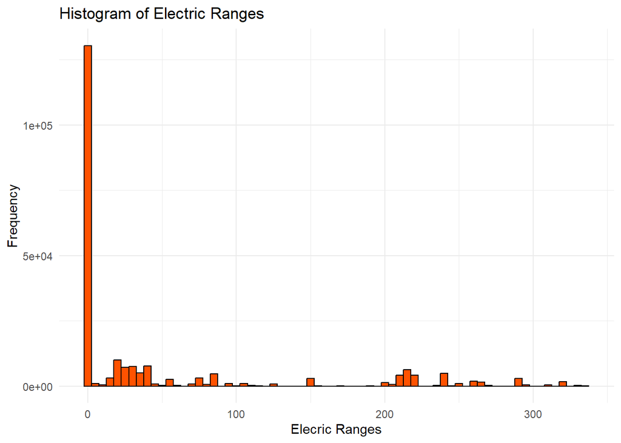

Yeah, I was unsure how many zeros were in this, but this just goes to show the difference in information.

Without 0

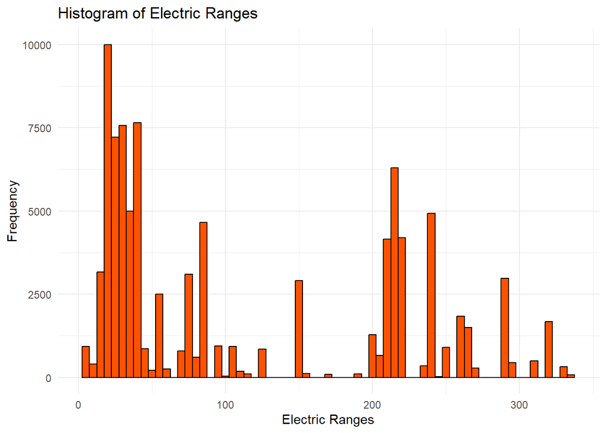

### Box Plot

With 0

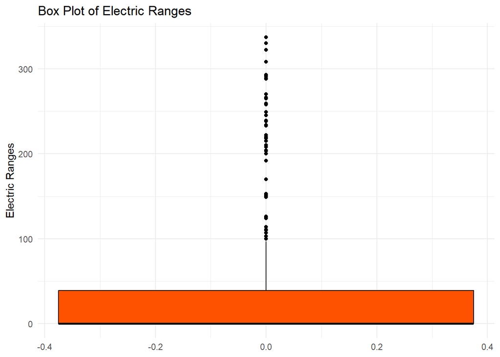

Without 0

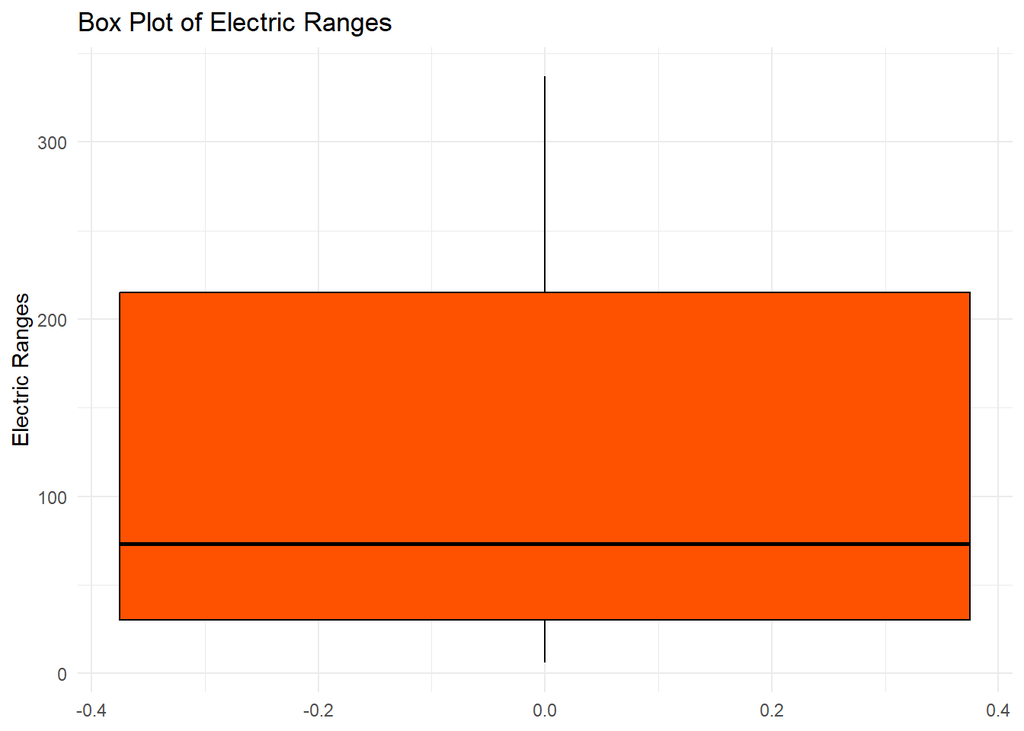

This box plot is more reasonable, but I feel like some information is missing because I believe that there are some entries that reach the 300s, and they should be outliers.

## B.

With 0

```r
cc <- cor(df$Model.Year, df$Electric.Range)

print(cc)
```

```
## [1] NA
```

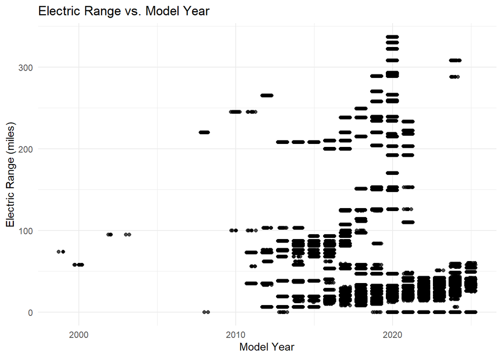

With all of the zeros, it is unable to fine a correlation, but by looking at the graph it seems that on average the newer the car, the better the range.

Without 0

```r
cc <- cor(no.zeros$Model.Year, no.zeros$Electric.Range)

print(cc)
```

```
## [1] -0.17499
```

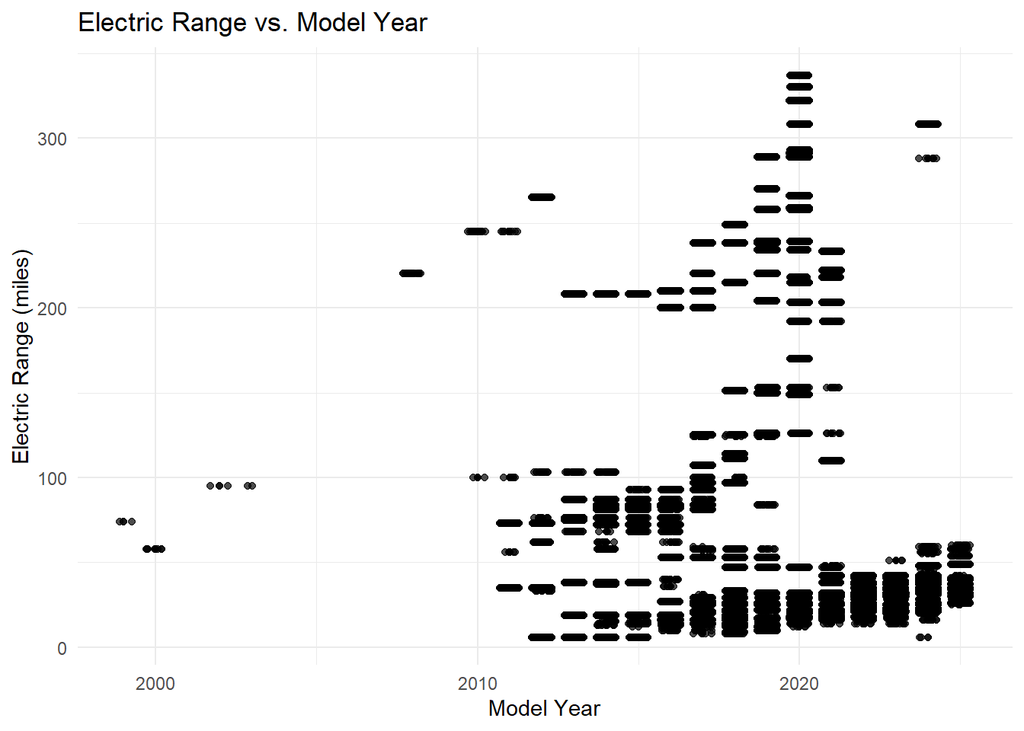

Well, the correlation coefficient kinda disproves my earlier statement, but only on a small scale.

## C.

### Frequency

| Make | Frequency |
| --- | --- |
| TESLA | 96180 |
| CHEVROLET | 16405 |
| NISSAN | 15259 |
| FORD | 11930 |
| KIA | 10760 |
| BMW | 9171 |
| TOYOTA | 8956 |
| HYUNDAI | 6878 |
| RIVIAN | 6236 |
| JEEP | 5773 |

The most frequent make of electric vehicle is Tesla. These are the top 10.

### Relative Frequency

| Make | Relative.Frequency |
| --- | --- |
| TESLA | 0.4293846 |
| CHEVROLET | 0.0732382 |
| NISSAN | 0.0681221 |
| FORD | 0.0532601 |
| KIA | 0.0480368 |
| BMW | 0.0409429 |
| TOYOTA | 0.0399830 |
| HYUNDAI | 0.0307060 |
| RIVIAN | 0.0278399 |
| JEEP | 0.0257729 |
| VOLKSWAGEN | 0.0256256 |
| VOLVO | 0.0248443 |
| AUDI | 0.0185584 |
| CHRYSLER | 0.0166656 |
| MERCEDES-BENZ | 0.0099958 |
| SUBARU | 0.0081698 |
| HONDA | 0.0080448 |
| PORSCHE | 0.0061475 |
| POLESTAR | 0.0054555 |
| MINI | 0.0048439 |
| MITSUBISHI | 0.0047546 |
| CADILLAC | 0.0045849 |
| MAZDA | 0.0040849 |
| LEXUS | 0.0038483 |
| FIAT | 0.0033840 |
| DODGE | 0.0032724 |
| LUCID | 0.0015938 |
| LINCOLN | 0.0015000 |
| GENESIS | 0.0014241 |
| GMC | 0.0013482 |
| SMART | 0.0010804 |
| JAGUAR | 0.0010402 |
| FISKER | 0.0008304 |
| ACURA | 0.0006295 |
| LAND ROVER | 0.0004464 |
| ALFA ROMEO | 0.0004063 |
| TH!NK | 0.0000223 |
| AZURE DYNAMICS | 0.0000179 |
| BENTLEY | 0.0000179 |
| BRIGHTDROP | 0.0000134 |
| ROLLS-ROYCE | 0.0000134 |
| WHEEGO ELECTRIC CARS | 0.0000134 |
| LAMBORGHINI | 0.0000089 |
| MULLEN AUTOMOTIVE INC. | 0.0000089 |
| RAM | 0.0000089 |
| VINFAST | 0.0000089 |

The difference between the first and second car is about 80000, so it makes sense that the relative frequency has such a big difference between them.

## D.

| Make | Electric Vehicle Type | Frequency | Relative_Frequency |
| --- | --- | --- | --- |
| TESLA | Battery Electric Vehicle (BEV) | 96180 | 0.4293846 |
| NISSAN | Battery Electric Vehicle (BEV) | 15259 | 0.0681221 |
| CHEVROLET | Battery Electric Vehicle (BEV) | 11685 | 0.0521663 |
| FORD | Battery Electric Vehicle (BEV) | 8234 | 0.0367597 |
| TOYOTA | Plug-in Hybrid Electric Vehicle (PHEV) | 7730 | 0.0345097 |
| KIA | Battery Electric Vehicle (BEV) | 7688 | 0.0343222 |
| RIVIAN | Battery Electric Vehicle (BEV) | 6236 | 0.0278399 |
| HYUNDAI | Battery Electric Vehicle (BEV) | 5883 | 0.0262640 |
| JEEP | Plug-in Hybrid Electric Vehicle (PHEV) | 5773 | 0.0257729 |
| VOLKSWAGEN | Battery Electric Vehicle (BEV) | 5740 | 0.0256256 |
| BMW | Plug-in Hybrid Electric Vehicle (PHEV) | 5567 | 0.0248532 |
| CHEVROLET | Plug-in Hybrid Electric Vehicle (PHEV) | 4720 | 0.0210719 |
| VOLVO | Plug-in Hybrid Electric Vehicle (PHEV) | 3751 | 0.0167459 |
| CHRYSLER | Plug-in Hybrid Electric Vehicle (PHEV) | 3733 | 0.0166656 |
| FORD | Plug-in Hybrid Electric Vehicle (PHEV) | 3696 | 0.0165004 |
| BMW | Battery Electric Vehicle (BEV) | 3604 | 0.0160896 |
| KIA | Plug-in Hybrid Electric Vehicle (PHEV) | 3072 | 0.0137146 |
| AUDI | Battery Electric Vehicle (BEV) | 2375 | 0.0106029 |
| VOLVO | Battery Electric Vehicle (BEV) | 1814 | 0.0080984 |
| AUDI | Plug-in Hybrid Electric Vehicle (PHEV) | 1782 | 0.0079555 |
| SUBARU | Battery Electric Vehicle (BEV) | 1737 | 0.0077546 |
| MERCEDES-BENZ | Battery Electric Vehicle (BEV) | 1708 | 0.0076252 |
| TOYOTA | Battery Electric Vehicle (BEV) | 1226 | 0.0054733 |
| POLESTAR | Battery Electric Vehicle (BEV) | 1222 | 0.0054555 |
| MITSUBISHI | Plug-in Hybrid Electric Vehicle (PHEV) | 1013 | 0.0045224 |
| HYUNDAI | Plug-in Hybrid Electric Vehicle (PHEV) | 995 | 0.0044421 |
| CADILLAC | Battery Electric Vehicle (BEV) | 940 | 0.0041965 |
| HONDA | Battery Electric Vehicle (BEV) | 939 | 0.0041921 |
| MAZDA | Plug-in Hybrid Electric Vehicle (PHEV) | 903 | 0.0040313 |
| MINI | Battery Electric Vehicle (BEV) | 863 | 0.0038528 |

[output cut: 62 more lines]

The cars are divided into their respective types, and the the frequency and relative frequency is given. Some of the proportions that are here are that there are more battery electric vehicles than plug-in or hybrids.

## E.

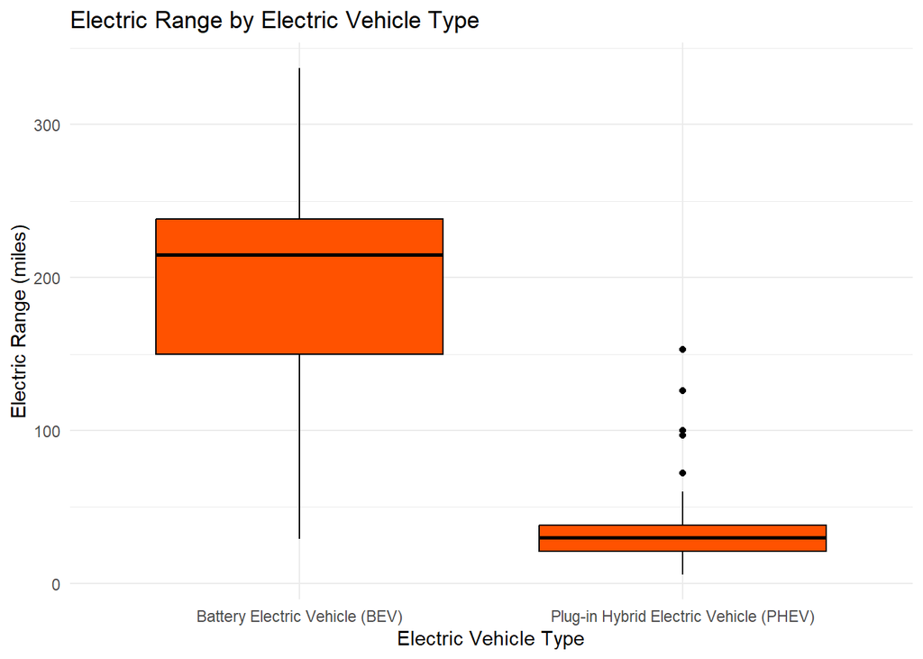

The boxplot shows the difference between BEV and PHEV, and just by looking at it the BEV category have a naturally higher range.

```r
ss <- no.zeros |>
  group_by(Electric.Vehicle.Type) |>
  summarise(
    Mean = mean(Electric.Range),
    SD = sd(Electric.Range),
    Median = median(Electric.Range),
    IQR = IQR(Electric.Range),
    Min = min(Electric.Range),
    Max = max(Electric.Range)
  )

kable(ss)
```

| Electric.Vehicle.Type | Mean | SD | Median | IQR | Min | Max |
| --- | --- | --- | --- | --- | --- | --- |
| Battery Electric Vehicle (BEV) | 197.69417 | 72.72783 | 215 | 88 | 29 | 337 |
| Plug-in Hybrid Electric Vehicle (PHEV) | 31.13038 | 14.73202 | 30 | 17 | 6 | 153 |

The summary statistics prove the previous statement by showing the math behind it.

## F.

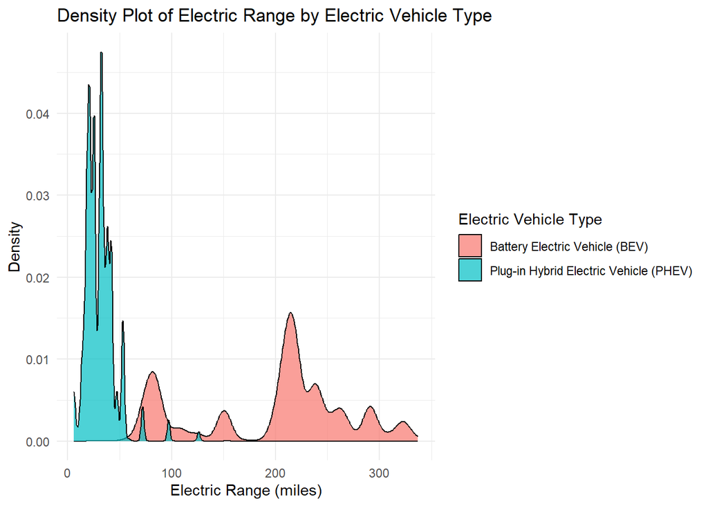

```r
ggplot(no.zeros, aes(x = Electric.Range, fill = Electric.Vehicle.Type)) +
  geom_density(alpha = 0.7) +
  labs(title = "Density Plot of Electric Range by Electric Vehicle Type",
       x = "Electric Range (miles)",
       y = "Density",
       fill = "Electric Vehicle Type") +
  theme_minimal()
```

The density plot shows that it is more common for there to be Plug-in Hybrids that range between 0 and 50 miles, and for Battery vehicles to be more spread about, with the majority of them having a range of a little over 200 miles.

# 3.

The dataset that I found is the Electric Car Population in the State of Washington. I found it on data.gov, after searching through several pages of data. I mostly used the type of car, make, model year, and electric ranges for the questions. I did have to modify the data just a little, because NA’s are not in this document, and they replaced them with 0 instead. I did test with both just to see the difference.

Link: https://catalog.data.gov/dataset/electric-vehicle-population-data

# Projet Part 2

I am going to go ahead and make a df that removes 0’s, because they are the place holders for Null

```r
df_clean <- df[df$Electric.Range != 0, ]
```

# 2.

## A.

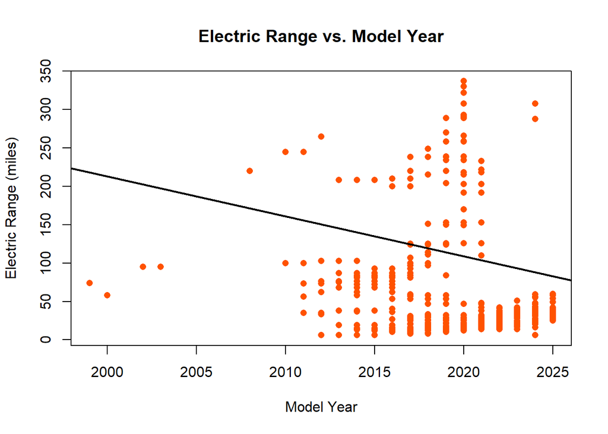

```
##
## Call:
## lm(formula = Electric.Range ~ Model.Year, data = df_clean)
##
## Residuals:
##     Min      1Q  Median      3Q     Max
## -155.18  -72.32  -51.11   95.62  228.04
##
## Coefficients:
##               Estimate Std. Error t value Pr(>|t|)
## (Intercept)  1.064e+04  1.936e+02   54.95   <2e-16 ***
## Model.Year  -5.211e+00  9.588e-02  -54.36   <2e-16 ***
## ---
## Signif. codes:  0 '***' 0.001 '**' 0.01 '*' 0.05 '.' 0.1 ' ' 1
##
## Residual standard error: 96.9 on 93533 degrees of freedom
##   (18 observations deleted due to missingness)
## Multiple R-squared:  0.03062,    Adjusted R-squared:  0.03061
## F-statistic:  2955 on 1 and 93533 DF,  p-value: < 2.2e-16
```

Well by looking at this data, and guessing on how technology advances as the future goes along, I would’ve thought that as the years go up the range goes up. Looking at the graph I am showed differently. There is a negative correlation, and I am not too sure as to why that would be other than there being a super dense population of low mileage newer cars. If the dataset had provided the MSRP, and not just left the column blank, perhaps I could have made a correlation and regression between range and MSRP.

## B.

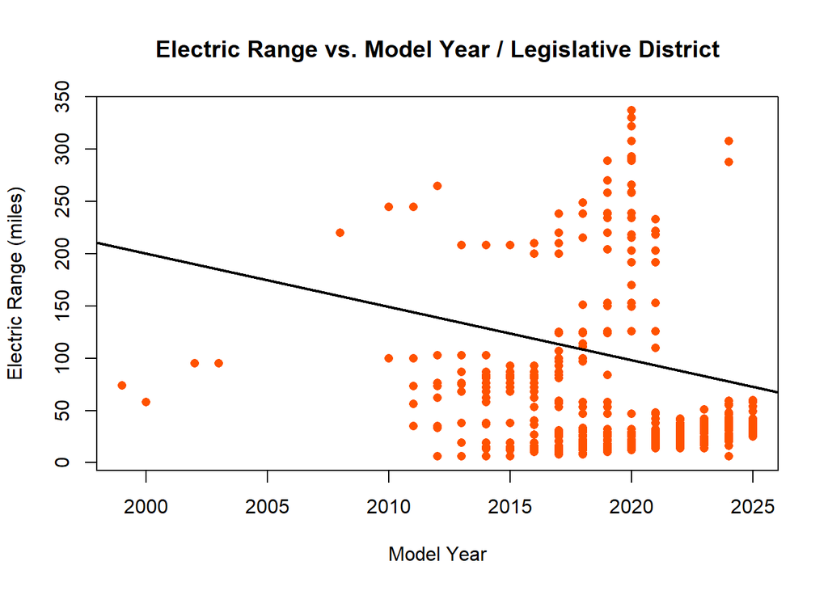

```
##
## Call:
## lm(formula = Electric.Range ~ Model.Year + Legislative.District,
##     data = df_clean)
##
## Residuals:
##     Min      1Q  Median      3Q     Max
## -158.33  -72.76  -51.41   93.57  238.54
##
## Coefficients:
##                        Estimate Std. Error t value Pr(>|t|)
## (Intercept)           1.040e+04  1.939e+02   53.65   <2e-16 ***
## Model.Year           -5.100e+00  9.600e-02  -53.13   <2e-16 ***
## Legislative.District  3.872e-01  2.167e-02   17.87   <2e-16 ***
## ---
## Signif. codes:  0 '***' 0.001 '**' 0.01 '*' 0.05 '.' 0.1 ' ' 1
##
## Residual standard error: 96.72 on 93298 degrees of freedom
##   (252 observations deleted due to missingness)
## Multiple R-squared:  0.03397,    Adjusted R-squared:  0.03395
## F-statistic:  1640 on 2 and 93298 DF,  p-value: < 2.2e-16
```

This doesn’t look any different, which makes me feel that there was no part that was changed. The MSRP column might’ve been more useful if the column actually had data within it. Also, by using the legislative district it does not actually benefit me in this situation. The summary is almost the same as the previous.

## C.

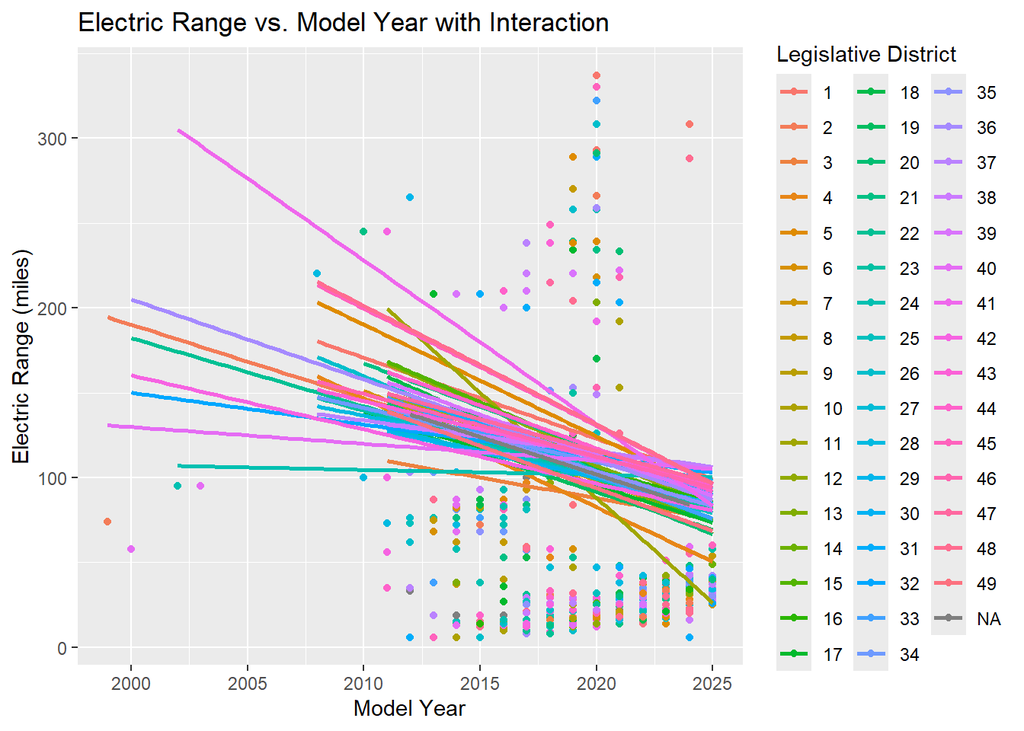

```
##
## Call:
## lm(formula = Electric.Range ~ Model.Year * Legislative.District,
##     data = df_clean)
##
## Residuals:
##     Min      1Q  Median      3Q     Max
## -159.41  -73.05  -50.16   93.43  239.66
##
## Coefficients:
##                                   Estimate Std. Error t value Pr(>|t|)
## (Intercept)                      1.336e+04  4.151e+02  32.185  < 2e-16 ***
## Model.Year                      -6.565e+00  2.055e-01 -31.940  < 2e-16 ***
## Legislative.District            -1.068e+02  1.330e+01  -8.031 9.81e-16 ***
## Model.Year:Legislative.District  5.310e-02  6.589e-03   8.060 7.74e-16 ***
## ---
## Signif. codes:  0 '***' 0.001 '**' 0.01 '*' 0.05 '.' 0.1 ' ' 1
##
## Residual standard error: 96.68 on 93297 degrees of freedom
##   (252 observations deleted due to missingness)
## Multiple R-squared:  0.03464,    Adjusted R-squared:  0.03461
## F-statistic:  1116 on 3 and 93297 DF,  p-value: < 2.2e-16
```

This graph is showing more than I was getting previously, but it is a little crowded.I am a little surprised that the legislative districts actually had an effect on the regression. My guess is that the legislative districts all vary in size, and that some of the lower mileage cars that are in them are not worse than older ones, but are instead designed that way because the people that live within them do not have to drive nearly as far. Therefor they do not need a high mileage to drive them places. Another theory is that there are more charging ports that are readily available, and car manufacturers know that and decided to build cheaper, not better.

## D.

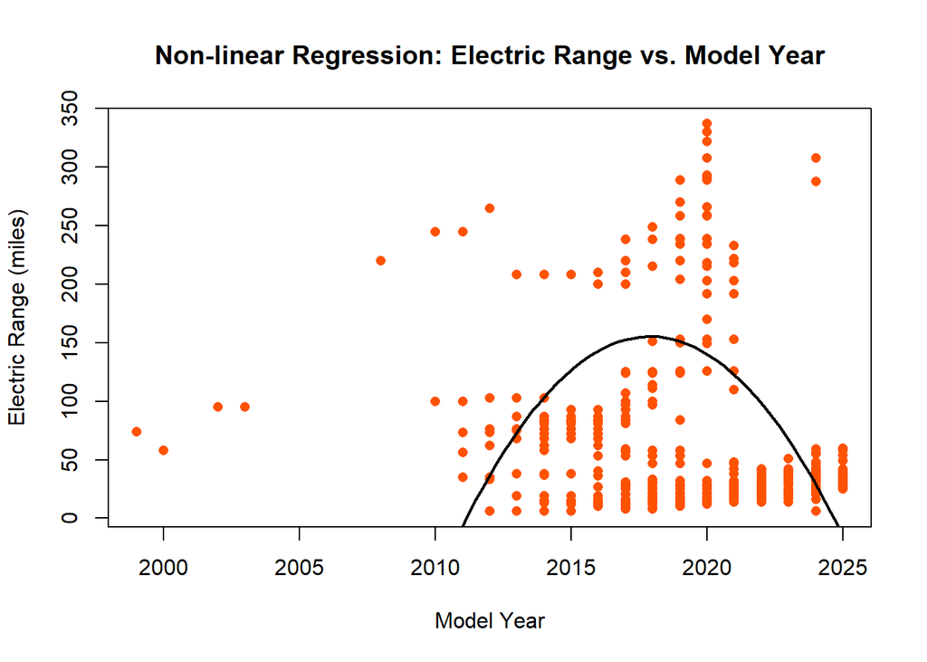

```
##
## Call:
## lm(formula = Electric.Range ~ Model.Year + Model_Year_Squared,
##     data = df_clean)
##
## Residuals:
##     Min      1Q  Median      3Q     Max
## -147.27  -66.23   -3.94   66.96 1132.18
##
## Coefficients:
##                      Estimate Std. Error t value Pr(>|t|)
## (Intercept)        -1.383e+07  8.641e+04  -160.1   <2e-16 ***
## Model.Year          1.371e+04  8.561e+01   160.1   <2e-16 ***
## Model_Year_Squared -3.397e+00  2.120e-02  -160.2   <2e-16 ***
## ---
## Signif. codes:  0 '***' 0.001 '**' 0.01 '*' 0.05 '.' 0.1 ' ' 1
##
## Residual standard error: 85.84 on 93532 degrees of freedom
##   (18 observations deleted due to missingness)
## Multiple R-squared:  0.2393, Adjusted R-squared:  0.2393
## F-statistic: 1.471e+04 on 2 and 93532 DF,  p-value: < 2.2e-16
```

```r
df_clean$Model_Year_Squared <- df_clean$Model.Year^2

nonlinear_model <- lm(Electric.Range ~ Model.Year + Model_Year_Squared, data = df_clean)

plot(df_clean$Model.Year, df_clean$Electric.Range,
     main = "Non-linear Regression: Electric Range vs. Model Year",
     xlab = "Model Year",
     ylab = "Electric Range (miles)",
     pch = 16, col = "#ff5200")

# Add the fitted curve
curve(predict(nonlinear_model, newdata = data.frame(Model.Year = x, Model_Year_Squared = x^2)),
      add = TRUE, col = "black", lwd = 2)
```

Using the model years, I squared them to allow me to have a nonlinear regression. Looking at the graph it actually does not look that bad. I already know that there is a negative regression line, but when it is squared it actually shows the spike between 2018-2020 of the newer cars with higher mileage. I have started to notice that the further along in the project that I go, the less material I actually have to work with.

# Project Part 3

# 2.

## A.

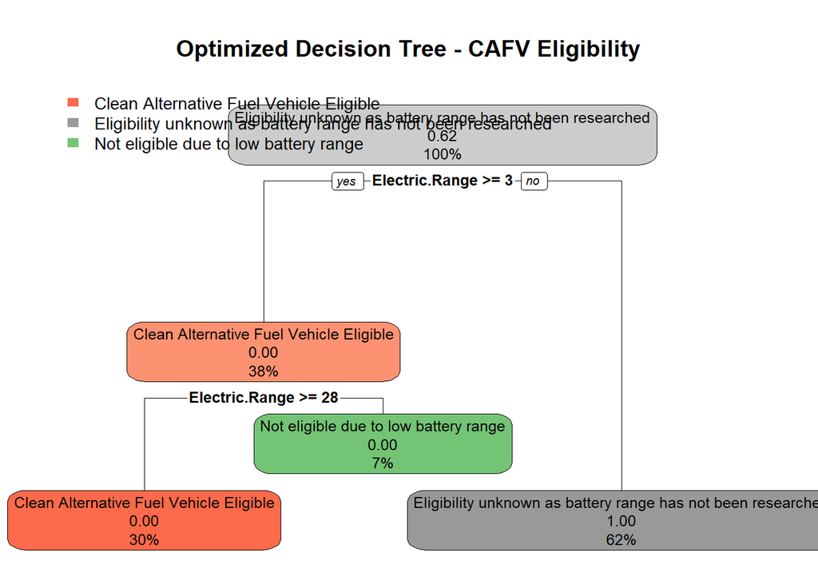

```
##                                                               preds
##                                                                Clean Alternative Fuel Vehicle Eligible
##   Clean Alternative Fuel Vehicle Eligible                                                           76
##   Eligibility unknown as battery range has not been researched                                       0
##   Not eligible due to low battery range                                                              0
##                                                               preds
##                                                                Eligibility unknown as battery range has not been researched
##   Clean Alternative Fuel Vehicle Eligible                                                                                 0
##   Eligibility unknown as battery range has not been researched                                                          156
##   Not eligible due to low battery range                                                                                   0
##                                                               preds
##                                                                Not eligible due to low battery range
##   Clean Alternative Fuel Vehicle Eligible                                                          0
##   Eligibility unknown as battery range has not been researched                                     0
##   Not eligible due to low battery range                                                           18
```

Okay for some reason I kept having issues running my decision tree. After crashing multiple times, restarting my PC, and contemplating dropping out of school, I got some outside help that recommended I break all of my code up into segments and run them by themselves. This worked, and I was able to get a decision tree. Now there is some bias to this tree, because the majority of the cars have not been tested for battery range. If I were to exclude them, I might be able to learn a little bit more. The matrix further backs this. Also, I used 250 random rows from the df to speed up the process.

## B.

```r
train_control <- trainControl(method = "cv", number = 5)

cv_model <- train(Clean.Alternative.Fuel.Vehicle..CAFV..Eligibility ~ .,
                  data = df_sample,
                  method = "rpart",
                  trControl = train_control)

print(cv_model)
```

```
## CART
##
## 250 samples
##   2 predictor
##   3 classes: 'Clean Alternative Fuel Vehicle Eligible', 'Eligibility unknown as battery range has not been researched', 'Not eligible due to low battery range'
##
## No pre-processing
## Resampling: Cross-Validated (5 fold)
## Summary of sample sizes: 199, 200, 200, 201, 200
## Resampling results across tuning parameters:
##
##   cp         Accuracy   Kappa
##   0.0000000  0.9959184  0.9916808
##   0.1914894  0.9482321  0.8969759
##   0.8085106  0.8068443  0.5052951
##
## Accuracy was used to select the optimal model using the largest value.
## The final value used for the model was cp = 0.
```

```r
cv_results <- cv_model$resample
print(cv_results)
```

```
##    Accuracy     Kappa Resample
## 1 1.0000000 1.0000000    Fold1
## 2 1.0000000 1.0000000    Fold2
## 3 1.0000000 1.0000000    Fold5
## 4 0.9795918 0.9584041    Fold4
## 5 1.0000000 1.0000000    Fold3
```

## C.

```r
knn_preds <- knn(train = trainData[, -1],
                 test = testData[, -1],
                 cl = trainData$Clean.Alternative.Fuel.Vehicle..CAFV..Eligibility,
                 k = 5)
```

```r
conf_matrix_knn <- confusionMatrix(knn_preds, testData$Clean.Alternative.Fuel.Vehicle..CAFV..Eligibility)
print(conf_matrix_knn)
```

```
## Confusion Matrix and Statistics
##
##                                                               Reference
## Prediction                                                     Clean Alternative Fuel Vehicle Eligible
##   Clean Alternative Fuel Vehicle Eligible                                                           21
##   Eligibility unknown as battery range has not been researched                                       0
##   Not eligible due to low battery range                                                              1
##                                                               Reference
## Prediction                                                     Eligibility unknown as battery range has not been researched
##   Clean Alternative Fuel Vehicle Eligible                                                                                 0
##   Eligibility unknown as battery range has not been researched                                                           46
##   Not eligible due to low battery range                                                                                   0
##                                                               Reference
## Prediction                                                     Not eligible due to low battery range
##   Clean Alternative Fuel Vehicle Eligible                                                          1
##   Eligibility unknown as battery range has not been researched                                     1
##   Not eligible due to low battery range                                                            3
##
## Overall Statistics
##
##                Accuracy : 0.9589
##                  95% CI : (0.8846, 0.9914)
##     No Information Rate : 0.6301
##     P-Value [Acc > NIR] : 3.09e-11
##
##                   Kappa : 0.9178
##
##  Mcnemar's Test P-Value : NA
##
## Statistics by Class:
##
##                      Class: Clean Alternative Fuel Vehicle Eligible
## Sensitivity                                                  0.9545
## Specificity                                                  0.9804
## Pos Pred Value                                               0.9545
## Neg Pred Value                                               0.9804
## Prevalence                                                   0.3014
## Detection Rate                                               0.2877
## Detection Prevalence                                         0.3014
## Balanced Accuracy                                            0.9675
##                      Class: Eligibility unknown as battery range has not been researched
## Sensitivity                                                                       1.0000
## Specificity                                                                       0.9630
## Pos Pred Value                                                                    0.9787
## Neg Pred Value                                                                    1.0000
## Prevalence                                                                        0.6301
## Detection Rate                                                                    0.6301
## Detection Prevalence                                                              0.6438
## Balanced Accuracy                                                                 0.9815
##                      Class: Not eligible due to low battery range
## Sensitivity                                               0.60000
## Specificity                                               0.98529
## Pos Pred Value                                            0.75000
## Neg Pred Value                                            0.97101
## Prevalence                                                0.06849
## Detection Rate                                            0.04110
## Detection Prevalence                                      0.05479
## Balanced Accuracy                                         0.79265
```

```r
train_control <- trainControl(method = "cv", number = 5)

knn_cv_model <- train(Clean.Alternative.Fuel.Vehicle..CAFV..Eligibility ~ .,
                      data = df_sample,
                      method = "knn",
                      trControl = train_control)

print(knn_cv_model)
```

```
## k-Nearest Neighbors
##
## 250 samples
##   3 predictor
##   3 classes: 'Clean Alternative Fuel Vehicle Eligible', 'Eligibility unknown as battery range has not been researched', 'Not eligible due to low battery range'
##
## No pre-processing
## Resampling: Cross-Validated (5 fold)
## Summary of sample sizes: 200, 201, 200, 199, 200
## Resampling results across tuning parameters:
##
##   k  Accuracy   Kappa
##   5  0.9519936  0.9052975
##   7  0.9681569  0.9375535
##   9  0.9520720  0.9044816
##
## Accuracy was used to select the optimal model using the largest value.
## The final value used for the model was k = 7.
```

I used KNN for the comparison, and the results are a little different than the decision tree but they are not supper far off. With a 95% and 96% accuracy, the models are very similar. Again, there could be some issues with the bias that just happens to be picked up on more by KNN, that is causing these high results, but they are still good none the less.